# Final_Code

Haley Aldred

04/12/2021

# Introduction

This report contains my code for examining my data set, which will be used in classifying and predicting forest cover types in Roosevelt National Forest in Colorado, USA. My data comes from the UCI Machine Learning Repository (https://archive.ics.uci.edu/ml/machine-learning-databases/covtype/).

# Preparation Work

## Loading Libraries

```r
library(ggplot2)
library(tidyverse)
library(dplyr)
library(psych)
library(GGally)
library(scales)
library(texreg)
library(corrplot)
library(caret)
library(lattice)
library(e1071)
library(class)
library(randomForest)
```

# Data Exploration

Loading the data.

```r
data <- read.csv("~/School/CIND820/data/covtype.data.gz", header=FALSE, stringsAsFactors=TRUE)
#View(data)
```

Looking at the first few rows of data.

```r
head(data)
```

```
##     V1  V2 V3  V4  V5   V6  V7  V8  V9  V10 V11 V12 V13 V14 V15 V16 V17 V18 V19
## 1 2596  51  3 258   0  510 221 232 148 6279   1   0   0   0   0   0   0   0   0
## 2 2590  56  2 212  -6  390 220 235 151 6225   1   0   0   0   0   0   0   0   0
## 3 2804 139  9 268  65 3180 234 238 135 6121   1   0   0   0   0   0   0   0   0
## 4 2785 155 18 242 118 3090 238 238 122 6211   1   0   0   0   0   0   0   0   0
## 5 2595  45  2 153  -1  391 220 234 150 6172   1   0   0   0   0   0   0   0   0
## 6 2579 132  6 300 -15   67 230 237 140 6031   1   0   0   0   0   0   0   0   0
##   V20 V21 V22 V23 V24 V25 V26 V27 V28 V29 V30 V31 V32 V33 V34 V35 V36 V37 V38
## 1   0   0   0   0   0   0   0   0   0   0   0   0   0   0   0   0   0   0   0
## 2   0   0   0   0   0   0   0   0   0   0   0   0   0   0   0   0   0   0   0
## 3   0   0   0   0   0   0   1   0   0   0   0   0   0   0   0   0   0   0   0
## 4   0   0   0   0   0   0   0   0   0   0   0   0   0   0   0   0   0   0   0
## 5   0   0   0   0   0   0   0   0   0   0   0   0   0   0   0   0   0   0   0
## 6   0   0   0   0   0   0   0   0   0   0   0   0   0   0   0   0   0   0   0
##   V39 V40 V41 V42 V43 V44 V45 V46 V47 V48 V49 V50 V51 V52 V53 V54 V55
## 1   0   0   0   0   1   0   0   0   0   0   0   0   0   0   0   0   5
## 2   0   0   0   0   1   0   0   0   0   0   0   0   0   0   0   0   5
## 3   0   0   0   0   0   0   0   0   0   0   0   0   0   0   0   0   2
## 4   0   0   0   0   0   1   0   0   0   0   0   0   0   0   0   0   2
## 5   0   0   0   0   1   0   0   0   0   0   0   0   0   0   0   0   5
## 6   0   0   0   0   1   0   0   0   0   0   0   0   0   0   0   0   2
```

Adding column names based off the *covtype.info* document.

```r
colnames(data)<-c("elev", "aspect", "slope", "hHydro", "vHydro", "hRoad", "hs09", "hs12", "hs15", "hFire", "wild1", "wild2", "wild3", "wild4", "s1", "s2", "s3", "s4", "s5", "s6", "s7", "s8", "s9", "s10", "s11", "s12", "s13", "s14", "s15", "s16", "s17", "s18", "s19", "s20", "s21", "s22", "s23", "s24", "s25", "s26", "s27", "s28", "s29", "s30", "s31", "s32", "s33", "s34", "s35", "s36", "s37", "s38", "s39", "s40", "treeType")
```

Verifying the column names have been updated.

```r
head(data)
```

```
##   elev aspect slope hHydro vHydro hRoad hs09 hs12 hs15 hFire wild1 wild2 wild3
## 1 2596     51     3    258      0   510  221  232  148  6279     1     0     0
## 2 2590     56     2    212     -6   390  220  235  151  6225     1     0     0
## 3 2804    139     9    268     65  3180  234  238  135  6121     1     0     0
## 4 2785    155    18    242    118  3090  238  238  122  6211     1     0     0
## 5 2595     45     2    153     -1   391  220  234  150  6172     1     0     0
## 6 2579    132     6    300    -15    67  230  237  140  6031     1     0     0
##   wild4 s1 s2 s3 s4 s5 s6 s7 s8 s9 s10 s11 s12 s13 s14 s15 s16 s17 s18 s19 s20
## 1     0  0  0  0  0  0  0  0  0  0   0   0   0   0   0   0   0   0   0   0   0
## 2     0  0  0  0  0  0  0  0  0  0   0   0   0   0   0   0   0   0   0   0   0
## 3     0  0  0  0  0  0  0  0  0  0   0   0   1   0   0   0   0   0   0   0   0
## 4     0  0  0  0  0  0  0  0  0  0   0   0   0   0   0   0   0   0   0   0   0
## 5     0  0  0  0  0  0  0  0  0  0   0   0   0   0   0   0   0   0   0   0   0
## 6     0  0  0  0  0  0  0  0  0  0   0   0   0   0   0   0   0   0   0   0   0
##   s21 s22 s23 s24 s25 s26 s27 s28 s29 s30 s31 s32 s33 s34 s35 s36 s37 s38 s39
## 1   0   0   0   0   0   0   0   0   1   0   0   0   0   0   0   0   0   0   0
## 2   0   0   0   0   0   0   0   0   1   0   0   0   0   0   0   0   0   0   0
## 3   0   0   0   0   0   0   0   0   0   0   0   0   0   0   0   0   0   0   0
## 4   0   0   0   0   0   0   0   0   0   1   0   0   0   0   0   0   0   0   0
## 5   0   0   0   0   0   0   0   0   1   0   0   0   0   0   0   0   0   0   0
## 6   0   0   0   0   0   0   0   0   1   0   0   0   0   0   0   0   0   0   0
##   s40 treeType
## 1   0        5
## 2   0        5
## 3   0        2
## 4   0        2
## 5   0        5
## 6   0        2
```

Looking at the last few rows of data.

```r
tail(data)
```

```
##        elev aspect slope hHydro vHydro hRoad hs09 hs12 hs15 hFire wild1 wild2
## 581007 2401    157    21     90     15   120  238  238  119   830     0     0
## 581008 2396    153    20     85     17   108  240  237  118   837     0     0
## 581009 2391    152    19     67     12    95  240  237  119   845     0     0
## 581010 2386    159    17     60      7    90  236  241  130   854     0     0
## 581011 2384    170    15     60      5    90  230  245  143   864     0     0
## 581012 2383    165    13     60      4    67  231  244  141   875     0     0
##        wild3 wild4 s1 s2 s3 s4 s5 s6 s7 s8 s9 s10 s11 s12 s13 s14 s15 s16 s17
## 581007     1     0  0  1  0  0  0  0  0  0  0   0   0   0   0   0   0   0   0
## 581008     1     0  0  1  0  0  0  0  0  0  0   0   0   0   0   0   0   0   0
## 581009     1     0  0  1  0  0  0  0  0  0  0   0   0   0   0   0   0   0   0
## 581010     1     0  0  1  0  0  0  0  0  0  0   0   0   0   0   0   0   0   0
## 581011     1     0  0  1  0  0  0  0  0  0  0   0   0   0   0   0   0   0   0
## 581012     1     0  0  1  0  0  0  0  0  0  0   0   0   0   0   0   0   0   0
##        s18 s19 s20 s21 s22 s23 s24 s25 s26 s27 s28 s29 s30 s31 s32 s33 s34 s35
## 581007   0   0   0   0   0   0   0   0   0   0   0   0   0   0   0   0   0   0
## 581008   0   0   0   0   0   0   0   0   0   0   0   0   0   0   0   0   0   0
## 581009   0   0   0   0   0   0   0   0   0   0   0   0   0   0   0   0   0   0
## 581010   0   0   0   0   0   0   0   0   0   0   0   0   0   0   0   0   0   0
## 581011   0   0   0   0   0   0   0   0   0   0   0   0   0   0   0   0   0   0
## 581012   0   0   0   0   0   0   0   0   0   0   0   0   0   0   0   0   0   0
##        s36 s37 s38 s39 s40 treeType
## 581007   0   0   0   0   0        3
## 581008   0   0   0   0   0        3
## 581009   0   0   0   0   0        3
## 581010   0   0   0   0   0        3
## 581011   0   0   0   0   0        3
## 581012   0   0   0   0   0        3
```

Verifying that there are no missing values.

```r
colSums(is.na(data))
```

```
##     elev   aspect    slope   hHydro   vHydro    hRoad     hs09     hs12
##        0        0        0        0        0        0        0        0
##     hs15    hFire    wild1    wild2    wild3    wild4       s1       s2
##        0        0        0        0        0        0        0        0
##       s3       s4       s5       s6       s7       s8       s9      s10
##        0        0        0        0        0        0        0        0
##      s11      s12      s13      s14      s15      s16      s17      s18
##        0        0        0        0        0        0        0        0
##      s19      s20      s21      s22      s23      s24      s25      s26
##        0        0        0        0        0        0        0        0
##      s27      s28      s29      s30      s31      s32      s33      s34
##        0        0        0        0        0        0        0        0
##      s35      s36      s37      s38      s39      s40 treeType
##        0        0        0        0        0        0        0
```

Getting rid of binary wilderness area type and soil type columns. This will be done by concatenating the binary columns, converting them to numeric, and finding the log of the binary number.

```r
data$wildArea<-paste(data$wild1,data$wild2,data$wild3,data$wild4,sep="")
data$wildArea<-as.numeric(as.character(data$wildArea))
data$area<-(4-log(data$wildArea,10))
```

Next, we will do the same procedure for the 40 different soil types.

```r
data$soilType<-paste(data$s1,data$s2,data$s3,data$s4,data$s5,data$s6,data$s7,data$s8,data$s9,data$s10,data$s11,data$s12,data$s13,data$s14,data$s15,data$s16,data$s17,data$s18,data$s19,data$s20,data$s21,data$s22,data$s23,data$s24,data$s25,data$s26,data$s27,data$s28,data$s29,data$s30,data$s31,data$s32,data$s33,data$s34,data$s35,data$s36,data$s37,data$s38,data$s39,data$s40, sep="")
data$soilTypes<-as.numeric(as.character(data$soilType))
data$soil<-(40-log(data$soilTypes,10))
```

Next, we will calculated the euclidean distance to water.

```r
data$edHydro = (data$hHydro^2+data$vHydro^2)^.5
```

```r
data<-select(data,-c(hHydro,vHydro,wild1,wild2,wild3,wild4,s1,s2,s3,s4,s5,s6,s7,s8,s9,s10,s11,s12,s13,s14,s15,s16,s17,s18,s19,s20,s21,s22,s23,s24,s25,s26,s27,s28,s29,s30,s31,s32,s33,s34,s35,s36,s37,s38,s39,s40,wildArea,soilType,soilTypes))
```

Verify the process worked.

```r
head(data)
```

```
##   elev aspect slope hRoad hs09 hs12 hs15 hFire treeType area soil  edHydro
## 1 2596     51     3   510  221  232  148  6279        5    1   29 258.0000
## 2 2590     56     2   390  220  235  151  6225        5    1   29 212.0849
## 3 2804    139     9  3180  234  238  135  6121        2    1   12 275.7698
## 4 2785    155    18  3090  238  238  122  6211        2    1   30 269.2360
## 5 2595     45     2   391  220  234  150  6172        5    1   29 153.0033
## 6 2579    132     6    67  230  237  140  6031        2    1   29 300.3748
```

```r
tail(data)
```

```
##        elev aspect slope hRoad hs09 hs12 hs15 hFire treeType area soil  edHydro
## 581007 2401    157    21   120  238  238  119   830        3    3    2 91.24144
## 581008 2396    153    20   108  240  237  118   837        3    3    2 86.68333
## 581009 2391    152    19    95  240  237  119   845        3    3    2 68.06614
## 581010 2386    159    17    90  236  241  130   854        3    3    2 60.40695
## 581011 2384    170    15    90  230  245  143   864        3    3    2 60.20797
## 581012 2383    165    13    67  231  244  141   875        3    3    2 60.13319
```

Identifying tree types, adding a column for tree name

```r
data$treeName = 'a'
data$treeName[data$treeType==1] = 'Spruce-fir'
data$treeName[data$treeType==2] = 'Lodgepole Pine'
data$treeName[data$treeType==3] = 'Ponderosa Pine'
data$treeName[data$treeType==4] = 'Cottonwood-Willow'
data$treeName[data$treeType==5] = 'Aspen'
data$treeName[data$treeType==6] = 'Douglas-fir'
data$treeName[data$treeType==7] = 'Krummholz'
```

Identifying areas, adding a column for area name

```r
data$areaName = 'a'
data$areaName[data$area==1] = 'Rawah'
data$areaName[data$area==2] = 'Neota'
data$areaName[data$area==3] = 'Comanche Peak'
data$areaName[data$area==4] = 'Cache La Poudre'
```

Looking at the structure of the data. We will first create a dataset without the names.

```r
forest<-select(data,-c(treeName,areaName))
forest<-forest %>% relocate(treeType,.after=edHydro)

str(forest)
```

```
## 'data.frame':    581012 obs. of  12 variables:
##  $ elev    : int  2596 2590 2804 2785 2595 2579 2606 2605 2617 2612 ...
##  $ aspect  : int  51 56 139 155 45 132 45 49 45 59 ...
##  $ slope   : int  3 2 9 18 2 6 7 4 9 10 ...
##  $ hRoad   : int  510 390 3180 3090 391 67 633 573 666 636 ...
##  $ hs09    : int  221 220 234 238 220 230 222 222 223 228 ...
##  $ hs12    : int  232 235 238 238 234 237 225 230 221 219 ...
##  $ hs15    : int  148 151 135 122 150 140 138 144 133 124 ...
##  $ hFire   : int  6279 6225 6121 6211 6172 6031 6256 6228 6244 6230 ...
##  $ area    : num  1 1 1 1 1 1 1 1 1 1 ...
##  $ soil    : num  29 29 12 30 29 29 29 29 29 29 ...
##  $ edHydro : num  258 212 276 269 153 ...
##  $ treeType: int  5 5 2 2 5 2 5 5 5 5 ...
```

Looking at the basic data statistics.

```r
summary(forest)
```

```
##       elev          aspect          slope          hRoad           hs09
##  Min.   :1859   Min.   :  0.0   Min.   : 0.0   Min.   :   0   Min.   :  0.0
##  1st Qu.:2809   1st Qu.: 58.0   1st Qu.: 9.0   1st Qu.:1106   1st Qu.:198.0
##  Median :2996   Median :127.0   Median :13.0   Median :1997   Median :218.0
##  Mean   :2959   Mean   :155.7   Mean   :14.1   Mean   :2350   Mean   :212.1
##  3rd Qu.:3163   3rd Qu.:260.0   3rd Qu.:18.0   3rd Qu.:3328   3rd Qu.:231.0
##  Max.   :3858   Max.   :360.0   Max.   :66.0   Max.   :7117   Max.   :254.0
##       hs12            hs15           hFire           area            soil
##  Min.   :  0.0   Min.   :  0.0   Min.   :   0   Min.   :1.000   Min.   : 1.00
##  1st Qu.:213.0   1st Qu.:119.0   1st Qu.:1024   1st Qu.:1.000   1st Qu.:20.00
##  Median :226.0   Median :143.0   Median :1710   Median :2.000   Median :29.00
##  Mean   :223.3   Mean   :142.5   Mean   :1980   Mean   :2.114   Mean   :24.36
##  3rd Qu.:237.0   3rd Qu.:168.0   3rd Qu.:2550   3rd Qu.:3.000   3rd Qu.:31.00
##  Max.   :254.0   Max.   :254.0   Max.   :7173   Max.   :4.000   Max.   :40.00
##     edHydro          treeType
##  Min.   :   0.0   Min.   :1.000
##  1st Qu.: 108.5   1st Qu.:1.000
##  Median : 229.5   Median :2.000
##  Mean   : 276.1   Mean   :2.051
##  3rd Qu.: 393.8   3rd Qu.:2.000
##  Max.   :1418.9   Max.   :7.000
```

The psych package will be used to take a closer look at the data.

```r
describe(forest)
```

```
##          vars      n    mean      sd  median trimmed     mad  min     max
## elev        1 581012 2959.37  279.98 2996.00 2983.39  259.46 1859 3858.00
## aspect      2 581012  155.66  111.91  127.00  150.10  126.02    0  360.00
## slope       3 581012   14.10    7.49   13.00   13.49    7.41    0   66.00
## hRoad       4 581012 2350.15 1559.25 1997.00 2203.24 1541.90    0 7117.00
## hs09        5 581012  212.15   26.77  218.00  215.09   23.72    0  254.00
## hs12        6 581012  223.32   19.77  226.00  225.11   17.79    0  254.00
## hs15        7 581012  142.53   38.27  143.00  143.36   37.06    0  254.00
## hFire       8 581012 1980.29 1324.20 1710.00 1797.61 1111.95    0 7173.00
## area        9 581012    2.11    1.06    2.00    2.06    1.48    1    4.00
## soil       10 581012   24.36    9.49   29.00   25.08    7.41    1   40.00
## edHydro    11 581012  276.07  217.05  229.48  250.21  204.43    0 1418.92
## treeType   12 581012    2.05    1.40    2.00    1.73    1.48    1    7.00
##            range  skew kurtosis   se
## elev     1999.00 -0.82     0.75 0.37
## aspect    360.00  0.40    -1.22 0.15
## slope      66.00  0.79     0.58 0.01
## hRoad    7117.00  0.71    -0.38 2.05
## hs09      254.00 -1.18     1.88 0.04
## hs12      254.00 -1.06     2.07 0.03
## hs15      254.00 -0.28     0.40 0.05
## hFire    7173.00  1.29     1.65 1.74
## area        3.00  0.09    -1.61 0.00
## soil       39.00 -0.70    -0.43 0.01
## edHydro  1418.92  1.13     1.36 0.28
## treeType    6.00  2.28     4.95 0.00
```

Lets create a table of the different tree types.

```r
table(data$treeName)
```

```
##
##             Aspen Cottonwood-Willow       Douglas-fir         Krummholz
##              9493              2747             17367             20510
##    Lodgepole Pine    Ponderosa Pine        Spruce-fir
##            283301             35754            211840
```

This means there are 211840 instances of tree type 1 (spruce/fir), 283301 instances of tree type 2 (lodgepole pine), 35754 instances of tree type 3 (ponderosa pine), 2747 instances of tree type 4 (cottonwood/willow), 9493 instances of tree type 5 (aspen), 17367 instances of tree type 6 (douglas-fir), and 20510 instances of tree type 7 (krummholz). Tree type 2, or lodgepole pine, is the most frequent tree type found in the national forest. Cottonwood/willow trees are the most rare tree type in the forest.

We will do the same for the wilderness areas and soil types.

```r
table(data$areaName)
```

```
##
## Cache La Poudre   Comanche Peak           Neota           Rawah
##           36968          253364           29884          260796
```

```r
table(data$soil)
```

```
##
##      1      2      3      4      5      6      7      8      9     10     11
##   3031   7525   4823  12396   1597   6575    105    179   1147  32634  12410
##     12     13     14     15     16     17     18     19     20     21     22
##  29971  17431    599      3   2845   3422   1899   4021   9259    838  33373
##     23     24     25     26     27     28     29     30     31     32     33
##  57752  21278    474   2589   1086    946 115247  30170  25666  52519  45154
##     34     35     36     37     38     39     40
##   1611   1891    119    298  15573  13806   8750
```

# Data Visualization

Let’s look at the distribution of elevation for the data set.

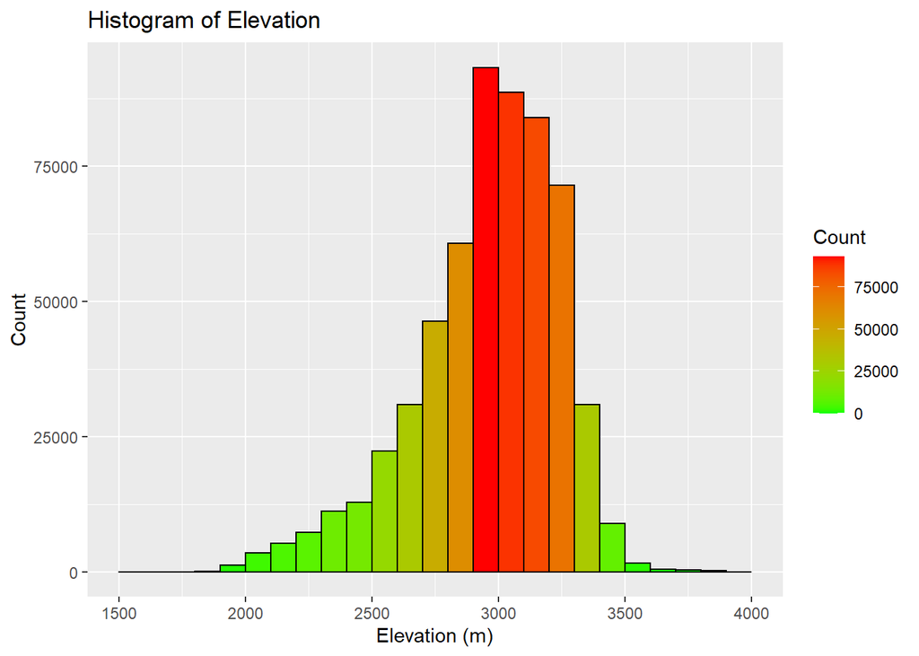

```r
ggplot(data, aes(x=elev))+geom_histogram(breaks=seq(1500,4000,by=100),col="black",aes(fill=..count..))+scale_fill_gradient("Count",low="green",high="red")+labs(title="Histogram of Elevation",x="Elevation (m)",y="Count")
```

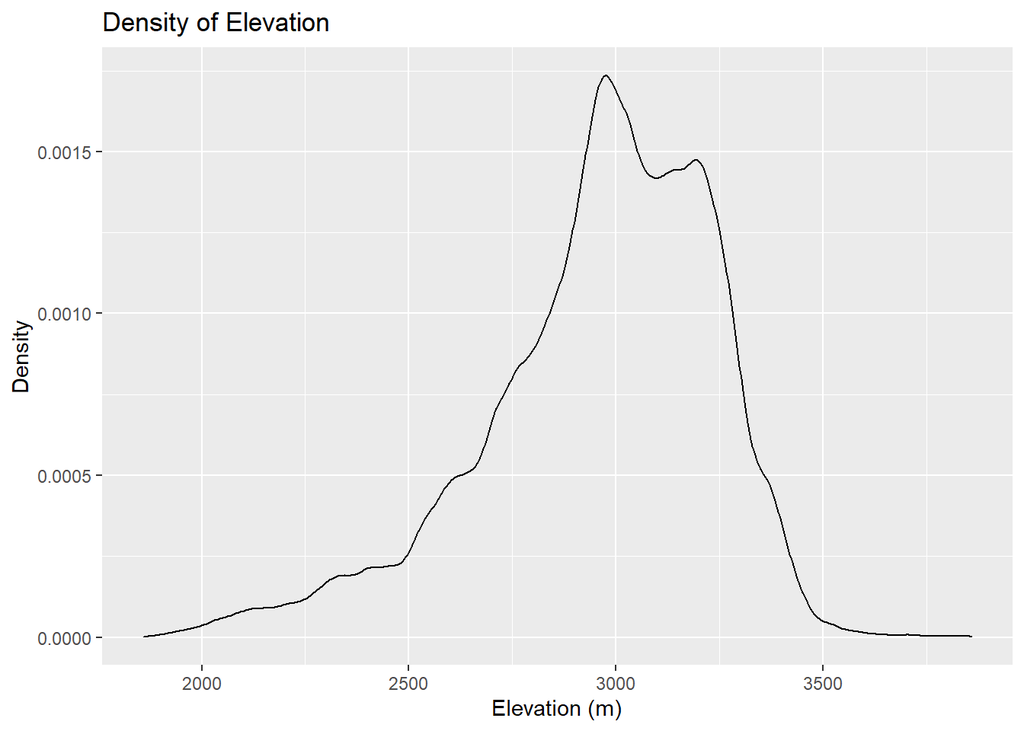

```r
ggplot(data, aes(x=elev)) + geom_density()+labs(title="Density of Elevation",x="Elevation (m)",y="Density")
```

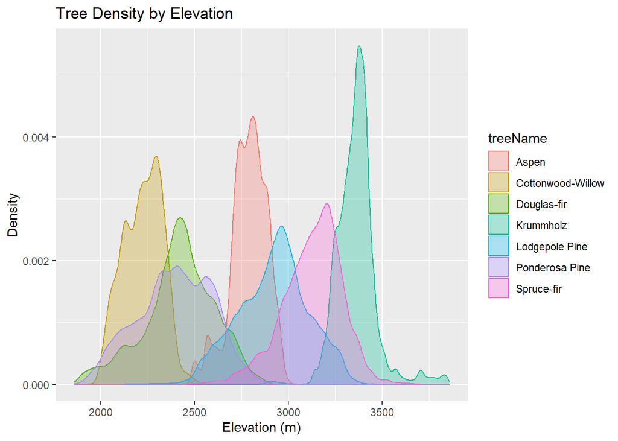

```r
ggplot(data, aes(x=elev)) + geom_density(aes(group=treeName, colour=treeName, fill=treeName), alpha=0.3)+labs(title="Tree Density by Elevation",x="Elevation (m)",y="Density")
```

Let’s look at the distribution of soil types for the data set.

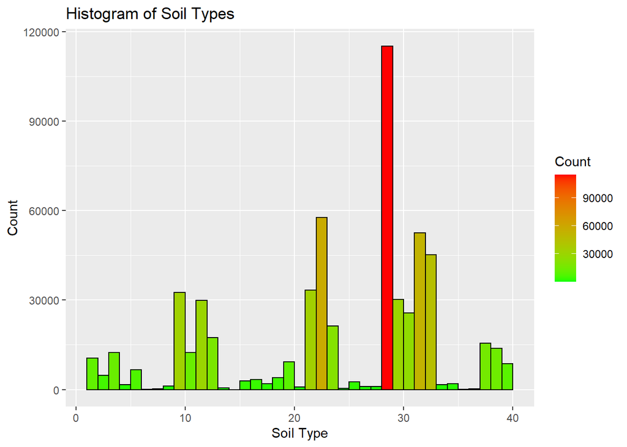

```r
ggplot(data=data, aes(soil))+geom_histogram(breaks=seq(1,40,by=1),col="black",aes(fill=..count..))+scale_fill_gradient("Count",low="green",high="red")+labs(title="Histogram of Soil Types",x="Soil Type",y="Count")
```

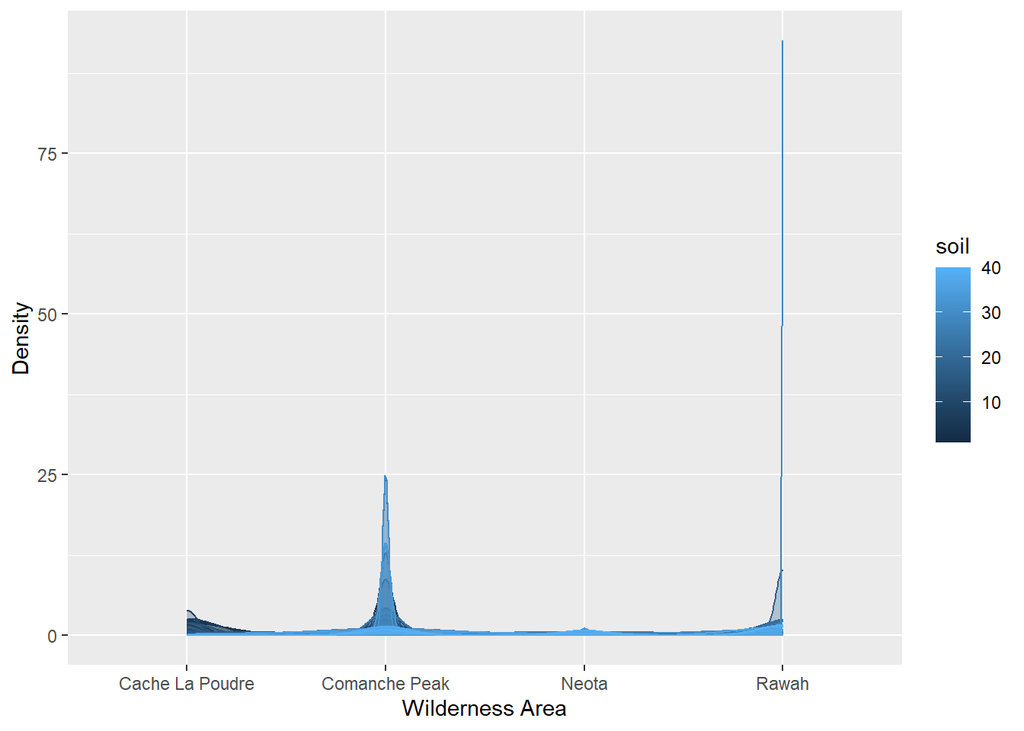

```r
ggplot(data,aes(areaName))+geom_density(aes(group=soil,colour=soil,fill=soil),alpha=0.3)+labs(main="Soils based on Wilderness Area",x="Wilderness Area",y="Density")
```

Let’s look at the distribution of tree types for the data set.

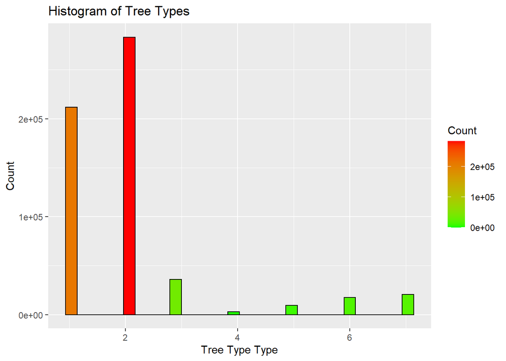

```r
ggplot(data=data, aes(treeType))+geom_histogram(col="black",aes(fill=..count..))+scale_fill_gradient("Count",low="green",high="red")+labs(title="Histogram of Tree Types",x="Tree Type Type",y="Count")
```

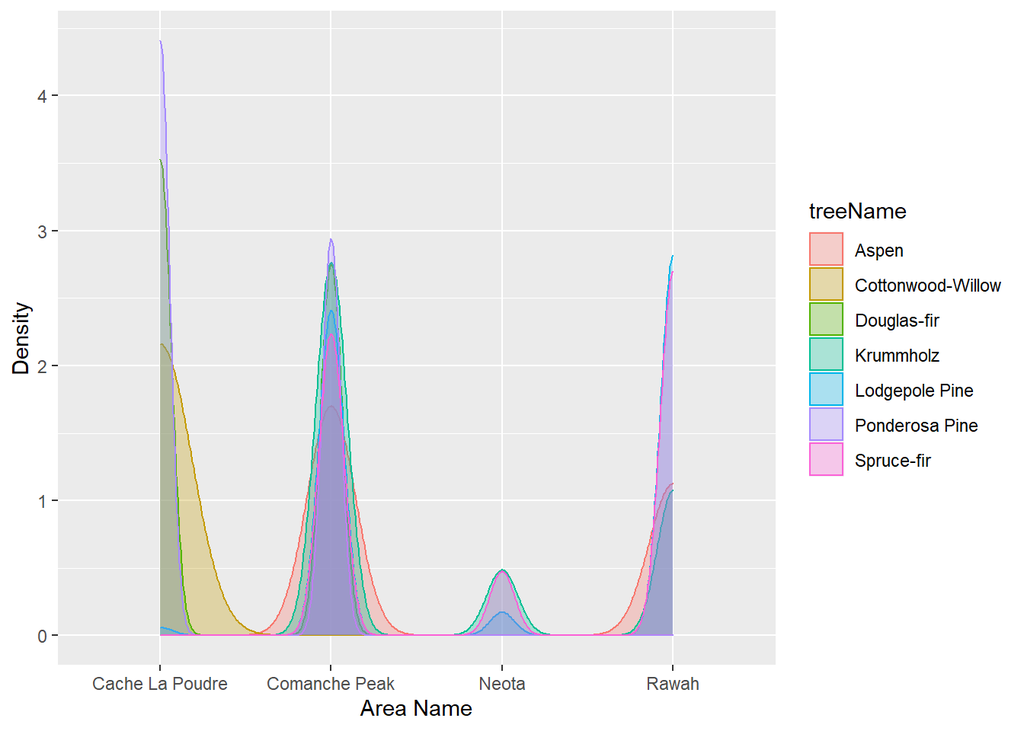

```r
ggplot(data, aes(x=areaName)) + geom_density(aes(group=treeName, colour=treeName, fill=treeName), alpha=0.3)+labs(main="Tree Density by Area",x="Area Name",y="Density")
```

Next, we will create a correlation matrix of the data.

```r
corForest<-cor(forest)
head(corForest)
```

```
##               elev      aspect       slope       hRoad        hs09        hs12
## elev    1.00000000  0.01573494 -0.24269664  0.36555928  0.11217930  0.20588691
## aspect  0.01573494  1.00000000  0.07872841  0.02512069 -0.57927291  0.33610296
## slope  -0.24269664  0.07872841  1.00000000 -0.21591416 -0.32719899 -0.52691064
## hRoad   0.36555928  0.02512069 -0.21591416  1.00000000  0.03434912  0.18946096
## hs09    0.11217930 -0.57927291 -0.32719899  0.03434912  1.00000000  0.01003685
## hs12    0.20588691  0.33610296 -0.52691064  0.18946096  0.01003685  1.00000000
##               hs15       hFire        area         soil      edHydro   treeType
## elev    0.05914778  0.14802156 -0.31558989  0.689848086  0.298044169 -0.2695538
## aspect  0.64694395 -0.10917150  0.13870259  0.007148751  0.021169187  0.0170798
## slope  -0.17585362 -0.18566195  0.28617814 -0.105570568  0.009285845  0.1482854
## hRoad   0.10611918  0.33157958 -0.44592246  0.240829308  0.064298904 -0.1534498
## hs09   -0.78029595  0.13266890 -0.23345480  0.040876904 -0.037468433 -0.0354150
## hs12    0.59427365  0.05732865 -0.08076668  0.013661836  0.036901414 -0.0964260
```

Now we will create a correlogram to visualize the correlation matrix.

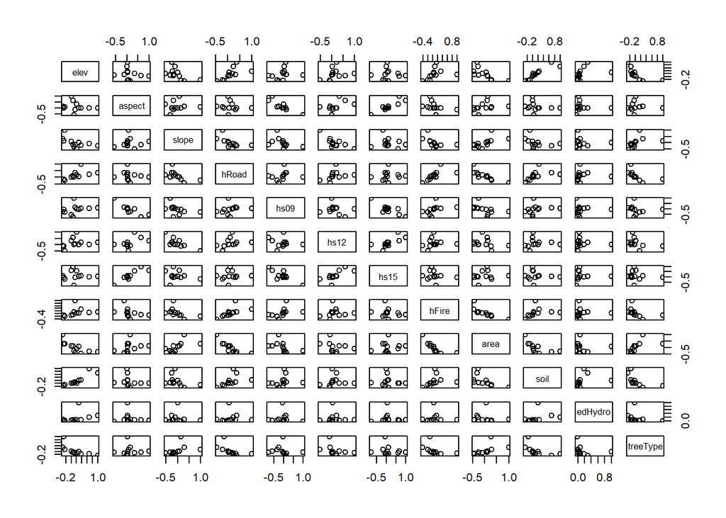

```r
pairs(corForest)
```

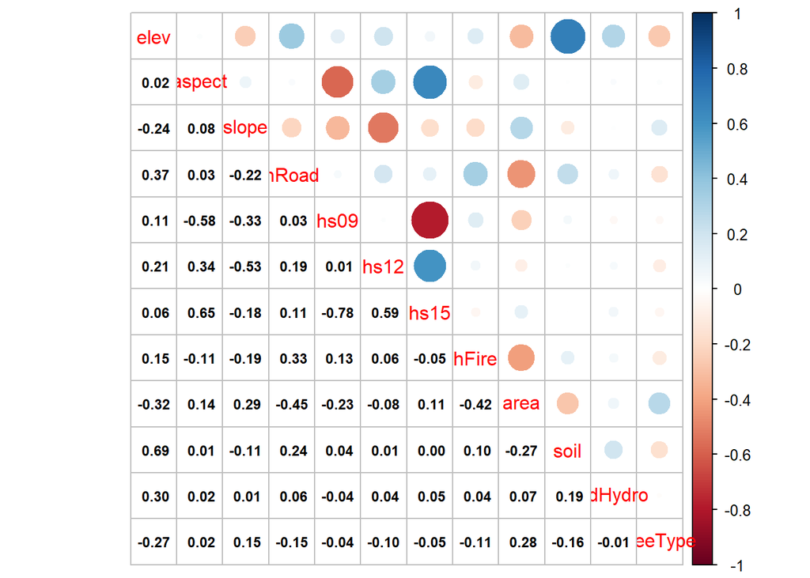

```r
corrplot.mixed(corForest,lower.col="black",number.cex=0.75)
```

Negative slopes show a negative correlation, while positive slopes show a positive correlation between two attributes. Attributes with the highest correlation to tree type include area.

# Data Analysis

We will split the data into testing and training samples for our detailed analysis. Due to RAM constraints, we will use a small subsection of the large data set.

```r
set.seed(42)
index1<- sample((1/100)*nrow(data), replace = FALSE)
data<- data[index1,]
forestN<-select(data,-c(treeName,areaName))
sample_size=round(nrow(forestN)*.70)
index<-sample(seq_len(nrow(forestN)),size=sample_size)
train<-forestN[index, ]
test<-forestN[-index, ]
```

## K-Nearest Neighbour Classification

The K-nearest neighbour algorithm will be used to predict the tree type based on other variables.

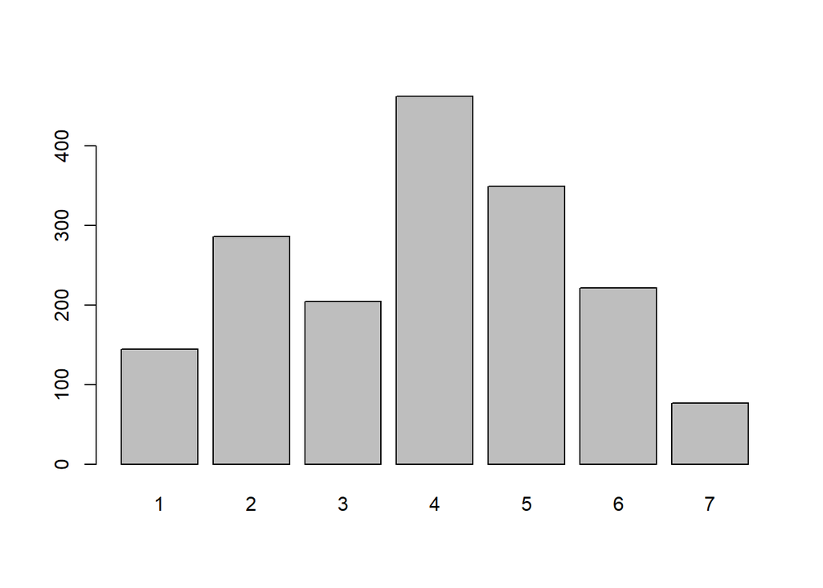

```r
k.predict<-knn(train = train[,1:12], test = test[,1:12], cl = as.factor(train$treeType), k = 3)
plot(k.predict)
```

The value for k (number of neighbours) was chosen by running the prediction model with different k values each time. Three was chosen as the best k value because it had the highest accuracy out of all the values tested.

Now let’s look at the confusion matrix to determine the accuracy and efficiency of the model.

```r
confMatrixK<-table(k.predict,test$treeType)
confusionMatrix(confMatrixK)
```

```
## Confusion Matrix and Statistics
##
##
## k.predict   1   2   3   4   5   6   7
##         1 100  40   0   0   2   0   2
##         2  56 219   2   0   5   3   1
##         3   0   3 165  10   0  26   0
##         4   0   0  45 399   1  17   0
##         5  11  42   2   0 289   5   0
##         6   0   8  27   9   1 176   0
##         7   4   4   0   0   0   0  69
##
## Overall Statistics
##
##                Accuracy : 0.813
##                  95% CI : (0.7939, 0.831)
##     No Information Rate : 0.2398
##     P-Value [Acc > NIR] : < 2.2e-16
##
##                   Kappa : 0.7746
##
##  Mcnemar's Test P-Value : NA
##
## Statistics by Class:
##
##                      Class: 1 Class: 2 Class: 3 Class: 4 Class: 5 Class: 6
## Sensitivity           0.58480   0.6930  0.68465   0.9545   0.9698   0.7753
## Specificity           0.97201   0.9530  0.97403   0.9525   0.9585   0.9703
## Pos Pred Value        0.69444   0.7657  0.80882   0.8636   0.8281   0.7964
## Neg Pred Value        0.95560   0.9334  0.95062   0.9852   0.9935   0.9665
## Prevalence            0.09811   0.1813  0.13827   0.2398   0.1710   0.1302
## Detection Rate        0.05737   0.1256  0.09466   0.2289   0.1658   0.1010
## Detection Prevalence  0.08262   0.1641  0.11704   0.2651   0.2002   0.1268
## Balanced Accuracy     0.77840   0.8230  0.82934   0.9535   0.9641   0.8728
##                      Class: 7
## Sensitivity           0.95833
## Specificity           0.99521
## Pos Pred Value        0.89610
## Neg Pred Value        0.99820
## Prevalence            0.04131
## Detection Rate        0.03959
## Detection Prevalence  0.04418
## Balanced Accuracy     0.97677
```

The accuracy of the model is 81%.

## Random Forest Classification

Now we will look at the Random Forest Classifier.

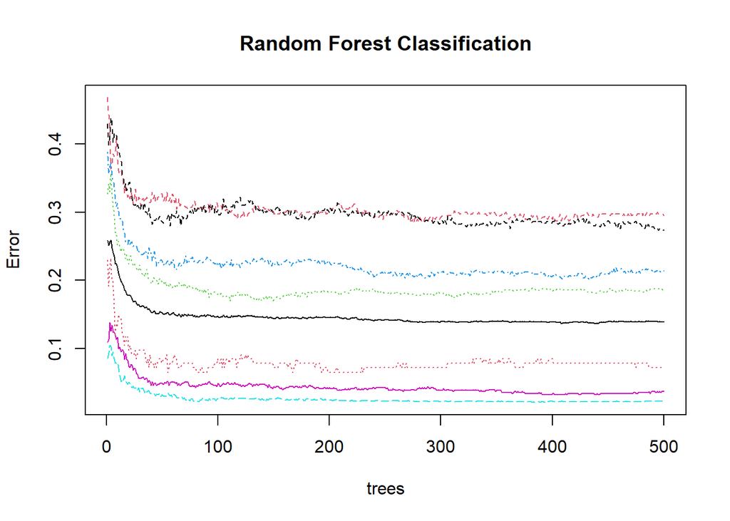

```r
classifier=randomForest(factor(train$treeType)~.,data=train)
plot(classifier,main="Random Forest Classification")
```

Now we will use the classifier to predict tree type.

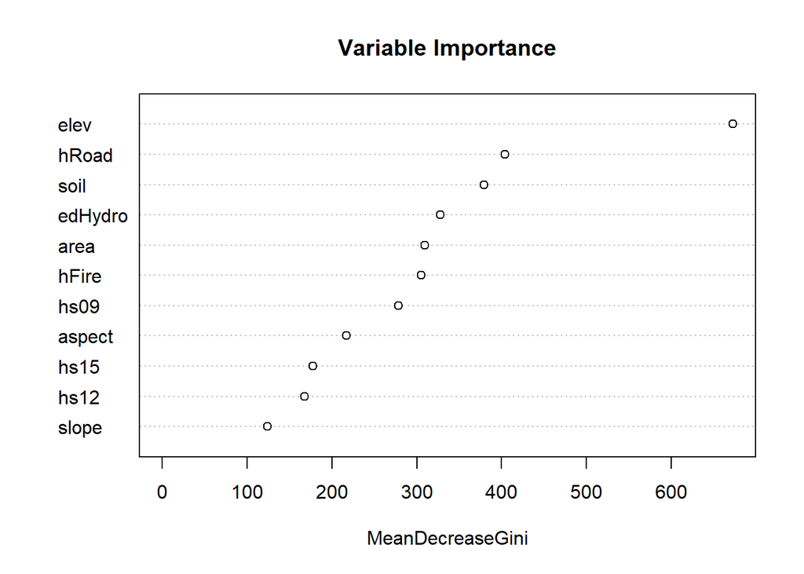

```r
rf.predict<-predict(classifier,test)
varImpPlot(classifier,main="Variable Importance")
```

The Variable importance plot shows the mean decrease in node impurity. Therefore elevation is an important indicator of tree type.

Looking at the confusion matrix.

```r
confMatrixTree<-table(rf.predict,test$treeType)
confusionMatrix(confMatrixTree)
```

```
## Confusion Matrix and Statistics
##
##
## rf.predict   1   2   3   4   5   6   7
##          1  96  37   0   0   1   0   3
##          2  61 251   0   0  11   1   0
##          3   0   3 197   6   0  42   0
##          4   0   0  23 410   0  16   0
##          5   7  23   1   0 282   4   0
##          6   0   1  20   2   4 164   0
##          7   7   1   0   0   0   0  69
##
## Overall Statistics
##
##                Accuracy : 0.8428
##                  95% CI : (0.8249, 0.8596)
##     No Information Rate : 0.2398
##     P-Value [Acc > NIR] : < 2.2e-16
##
##                   Kappa : 0.8106
##
##  Mcnemar's Test P-Value : NA
##
## Statistics by Class:
##
##                      Class: 1 Class: 2 Class: 3 Class: 4 Class: 5 Class: 6
## Sensitivity           0.56140   0.7943   0.8174   0.9809   0.9463  0.72247
## Specificity           0.97392   0.9488   0.9660   0.9706   0.9758  0.98219
## Pos Pred Value        0.70073   0.7747   0.7944   0.9131   0.8896  0.85864
## Neg Pred Value        0.95330   0.9542   0.9706   0.9938   0.9888  0.95941
## Prevalence            0.09811   0.1813   0.1383   0.2398   0.1710  0.13024
## Detection Rate        0.05508   0.1440   0.1130   0.2352   0.1618  0.09409
## Detection Prevalence  0.07860   0.1859   0.1423   0.2576   0.1819  0.10958
## Balanced Accuracy     0.76766   0.8716   0.8917   0.9757   0.9610  0.85233
##                      Class: 7
## Sensitivity           0.95833
## Specificity           0.99521
## Pos Pred Value        0.89610
## Neg Pred Value        0.99820
## Prevalence            0.04131
## Detection Rate        0.03959
## Detection Prevalence  0.04418
## Balanced Accuracy     0.97677
```

The accuracy of the Random Forest model is 84%. ```